# AllLife Bank Customer Segmentation

## Treat Outliers

```python
outliers_pallete                   = {"Normal":"#4caf50", "Outlier":"#FF0000", "Default":"#00c853"}
Main_Outliers_Df_labeled           = main_data.copy()
Main_Outliers_Df_labeled['labels'] = 'Normal'
```

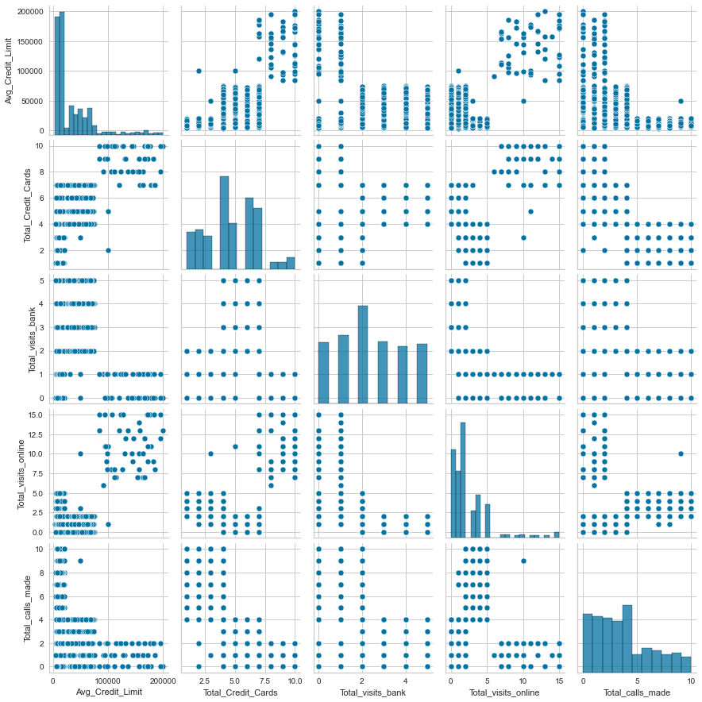

```python
sns.pairplot(
    data    = main_data.iloc[:,1:7],
    kind    = "scatter",
    palette = default_color_palette)
```

```python
'''
Input:
Outliers_Df : A filtered dataframe that contains only outliers.
Labeled_Df  : A dataframe to mark the outliers on
Features    : A list of two features to treat outliers for.

Results:
plots a scatter plot with outliers labeled.
returns Labeled_Df with outliers labeled.

Required:
Labeled_Df must have a column named 'labels' which telle if a row is an ourlier or not.
'''
def MarkOutliers(Outliers_Df, Labeled_Df, Features, ShowPlot = True):
    outlier_customers_ids = Outliers_Df[CUSTOMER_PRIMARY_KEY].to_list()

    def SetOutlierLabel(x):
        if x[CUSTOMER_PRIMARY_KEY] in outlier_customers_ids:
           x['labels'] = 'Outlier'
        return x

    Labeled_Df = Labeled_Df.apply(SetOutlierLabel, axis=1)

    if ShowPlot:
        fig, ax = plt.subplots(figsize=(10, 10))
        ax = sns.scatterplot(data=Labeled_Df, x=Features["x"], y=Features["y"], hue='labels', palette=outliers_pallete, ax=ax)
        ax.set(title=f'Outlier Treatment for {Features["x"]} v.s. {Features["y"]}')
        ax.legend(loc='center left', bbox_to_anchor=(1, 0.5))
        plt.show()

    return Labeled_Df

'''
Plot a scatter plot for the given features and dataframe.
'''
def ScatterPlotBeforeOutlierTreatment(Df, Features):
    fig, ax = plt.subplots(figsize=(15, 10))
    ax = sns.scatterplot(data=Df, x=Features["x"], y=Features["y"], palette=outliers_pallete, ax=ax)
    ax.set(title=f'{Features["x"]} v.s. {Features["y"]}')
    plt.show()

'''
Input:
given a outlier constrains ins the form:
Outlier_Constrains = [
    [
        labeled_df['Avg_Credit_Limit'] >= 100000,
        labeled_df['Total_Credit_Cards'] >= 2,
        labeled_df['Total_Credit_Cards'] <= 5,
    ],
    [
        labeled_df['Avg_Credit_Limit'] >= 50000,
        labeled_df['Total_Credit_Cards'] < 4
    ]
]

Output:
it filters out all the outliers in that constraint list and returns
a dataframe containing those outliers.
'''
def GetOutlierSDataFrame(df, outlier_constraints):
    outlier_constraint_dfs = []
    for constraint_set in outlier_constraints:
        temp_df = df.copy()
        for constrain in constraint_set:
            temp_df = temp_df[constrain]
        outlier_constraint_dfs.append(temp_df)
    return pd.concat(outlier_constraint_dfs,axis=0)
```

#### Outlier Treatment for Total_Credit_Cards v.s. Avg_Credit_Limit

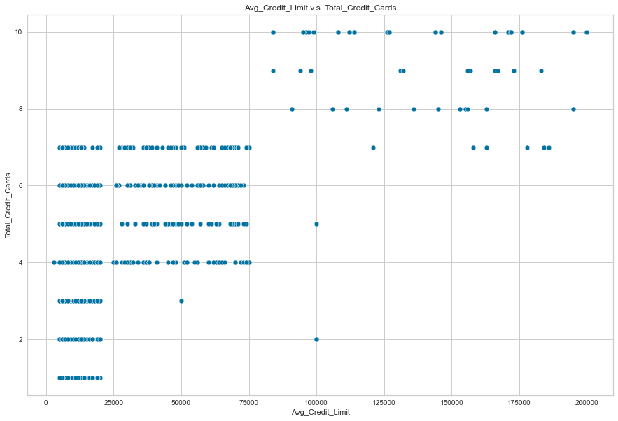

```python
labeled_df           = main_data.copy()
labeled_df['labels'] = 'Normal'

features = {'x':'Avg_Credit_Limit', 'y':'Total_Credit_Cards'}
ScatterPlotBeforeOutlierTreatment(labeled_df, features)
```

```python
# Create outlier Constraints
Outlier_Constrains = [
    [
        labeled_df['Avg_Credit_Limit'] >= 100000,
        labeled_df['Total_Credit_Cards'] >= 2,
        labeled_df['Total_Credit_Cards'] <= 5,
    ],
    [
        labeled_df['Avg_Credit_Limit'] >= 50000,
        labeled_df['Total_Credit_Cards'] < 4
    ]
]
```

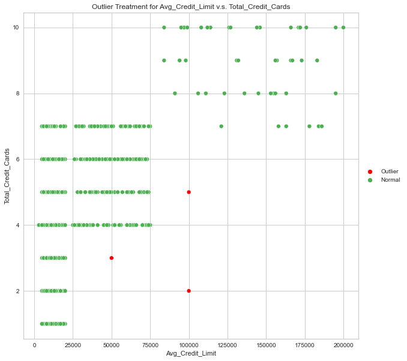

```python
outliers_df = GetOutlierSDataFrame(labeled_df, Outlier_Constrains)

MarkOutliers(
    Outliers_Df = outliers_df,
    Labeled_Df  = labeled_df,
    Features    = features)

Main_Outliers_Df_labeled = MarkOutliers(
    Outliers_Df = outliers_df,
    Labeled_Df  = Main_Outliers_Df_labeled,
    Features    = features,
    ShowPlot    = False)
```

#### Outlier Treatment for Total_visits_bank v.s. Avg_Credit_Limit

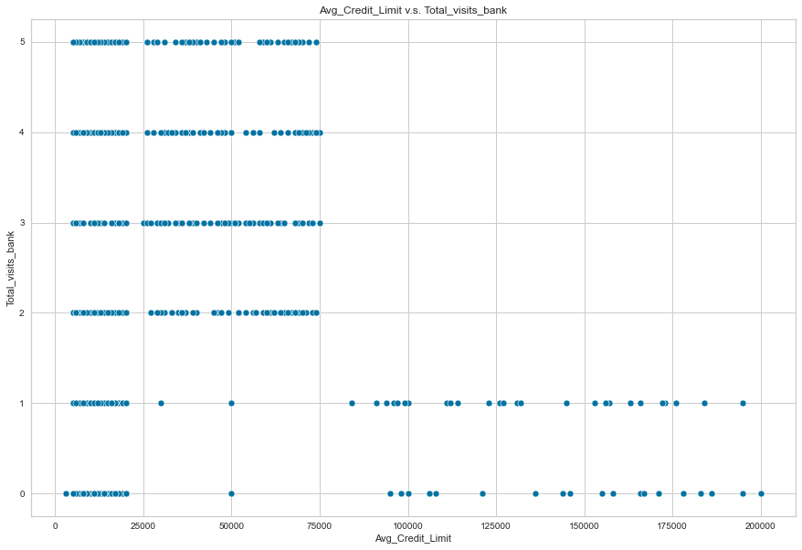

```python
labeled_df           = main_data.copy()
labeled_df['labels'] = 'Normal'

features = {'x':'Avg_Credit_Limit', 'y':'Total_visits_bank'}
ScatterPlotBeforeOutlierTreatment(labeled_df, features)
```

```python
# Create outlier Constraints
Outlier_Constrains = [
    [
        labeled_df['Total_visits_bank'] < 2,
        labeled_df['Avg_Credit_Limit'] >= 25000,
        labeled_df['Avg_Credit_Limit'] <= 75000,
    ]
]
```

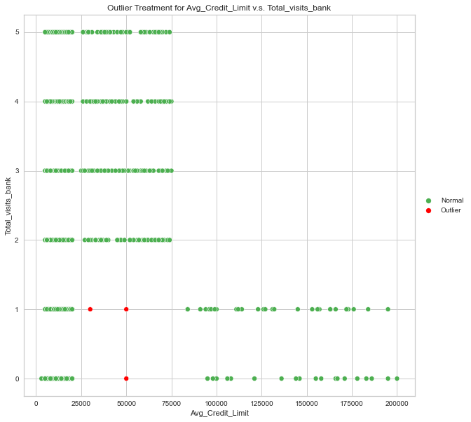

```python
outliers_df = GetOutlierSDataFrame(labeled_df, Outlier_Constrains)

MarkOutliers(
    Outliers_Df = outliers_df,
    Labeled_Df  = labeled_df,
    Features    = features)

Main_Outliers_Df_labeled = MarkOutliers(
    Outliers_Df = outliers_df,
    Labeled_Df  = Main_Outliers_Df_labeled,
    Features    = features,
    ShowPlot    = False)
```

#### Outlier Treatment for Total_calls_made v.s. Avg_Credit_Limit

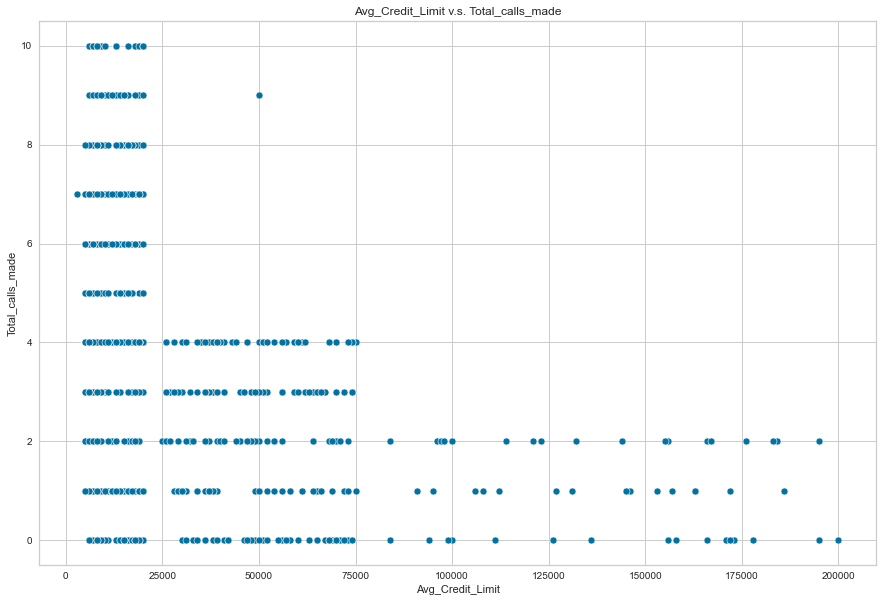

```python
labeled_df           = main_data.copy()
labeled_df['labels'] = 'Normal'

features = {'x':'Avg_Credit_Limit', 'y':'Total_calls_made'}
ScatterPlotBeforeOutlierTreatment(labeled_df, features)
```

```python
# Create outlier Constraints
Outlier_Constrains = [
    [
        labeled_df['Total_calls_made'] >= 5,
        labeled_df['Avg_Credit_Limit'] >= 50000
    ]
]
```

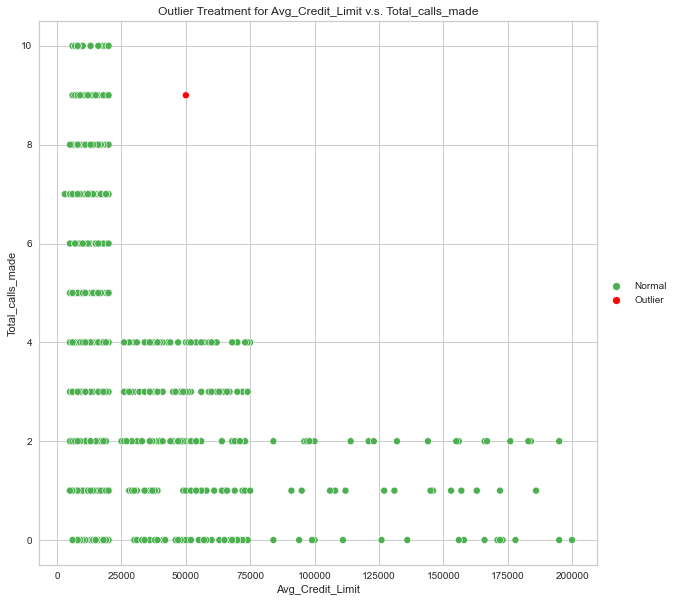

```python
outliers_df = GetOutlierSDataFrame(labeled_df, Outlier_Constrains)

MarkOutliers(
    Outliers_Df = outliers_df,
    Labeled_Df  = labeled_df,
    Features    = features)

Main_Outliers_Df_labeled = MarkOutliers(
    Outliers_Df = outliers_df,
    Labeled_Df  = Main_Outliers_Df_labeled,
    Features    = features,
    ShowPlot    = False)
```

#### Outlier Treatment for Total_visits_online v.s. Avg_Credit_Limit

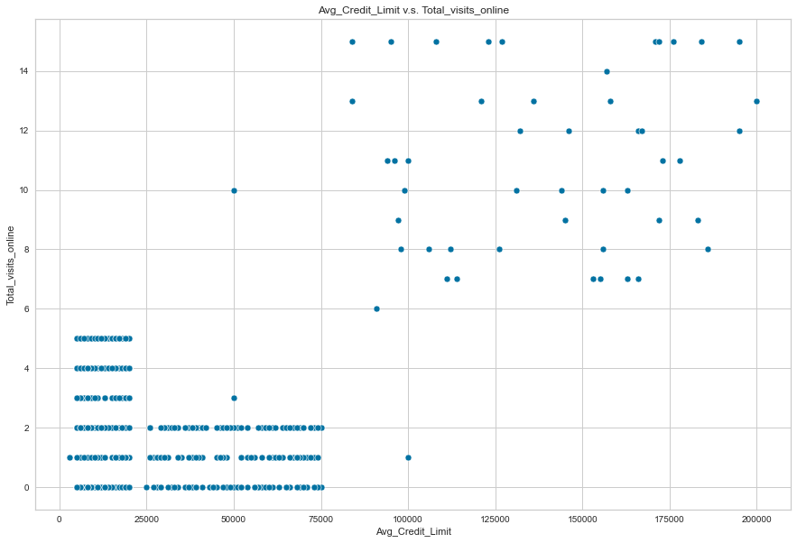

```python
labeled_df           = main_data.copy()
labeled_df['labels'] = 'Normal'

features = {'x':'Avg_Credit_Limit', 'y':'Total_visits_online'}
ScatterPlotBeforeOutlierTreatment(labeled_df, features)
```

```python
# Create outlier Constraints
Outlier_Constrains = [
    [
        labeled_df['Total_visits_online'] >= 3,
        labeled_df['Avg_Credit_Limit'] <= 75000,
        labeled_df['Avg_Credit_Limit'] >= 25000
    ],
    [
        labeled_df['Total_visits_online'] < 4,
        labeled_df['Avg_Credit_Limit'] > 80000,
    ]
]
```

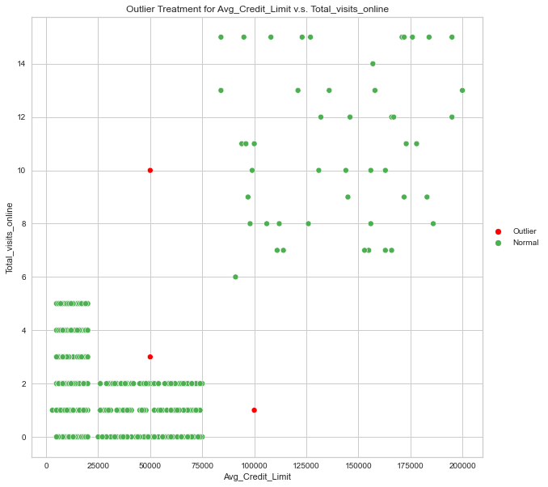

```python
outliers_df = GetOutlierSDataFrame(labeled_df, Outlier_Constrains)

MarkOutliers(
    Outliers_Df = outliers_df,
    Labeled_Df  = labeled_df,
    Features    = features)

Main_Outliers_Df_labeled = MarkOutliers(
    Outliers_Df = outliers_df,
    Labeled_Df  = Main_Outliers_Df_labeled,
    Features    = features,
    ShowPlot    = False)
```

#### Outlier Treatment for Total_visits_bank v.s. Total_Credit_Cards

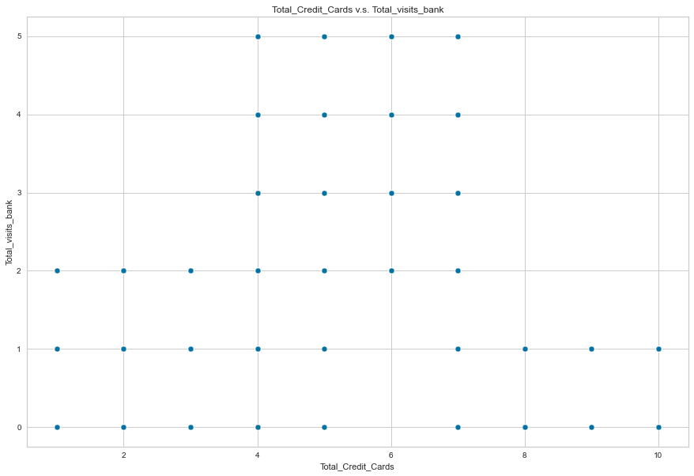

```python
labeled_df           = main_data.copy()
labeled_df['labels'] = 'Normal'

features = {'x':'Total_Credit_Cards', 'y':'Total_visits_bank'}
ScatterPlotBeforeOutlierTreatment(labeled_df, features)
```

```python
# Create outlier Constraints
Outlier_Constrains = [
    [
        labeled_df['Total_Credit_Cards'] >= 5,
        labeled_df['Total_Credit_Cards'] <= 6,
        labeled_df['Total_visits_bank'] < 2,
    ]
]
```

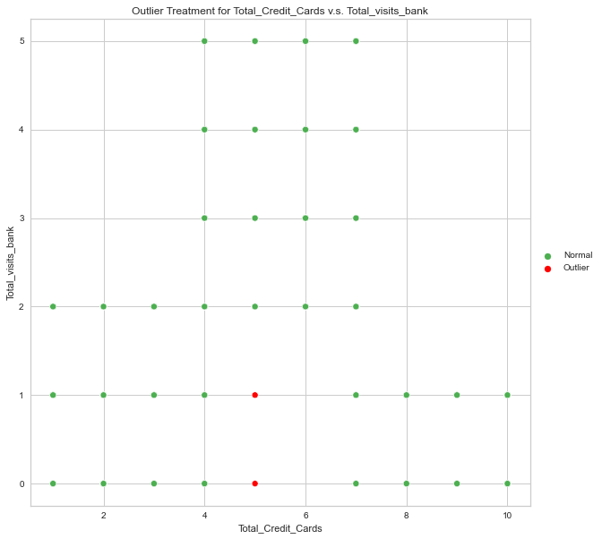

```python
outliers_df = GetOutlierSDataFrame(labeled_df, Outlier_Constrains)

MarkOutliers(
    Outliers_Df = outliers_df,
    Labeled_Df  = labeled_df,
    Features    = features)

Main_Outliers_Df_labeled = MarkOutliers(
    Outliers_Df = outliers_df,
    Labeled_Df  = Main_Outliers_Df_labeled,
    Features    = features,
    ShowPlot    = False)
```

#### Outlier Treatment for Total_visits_online v.s. Total_Credit_Cards

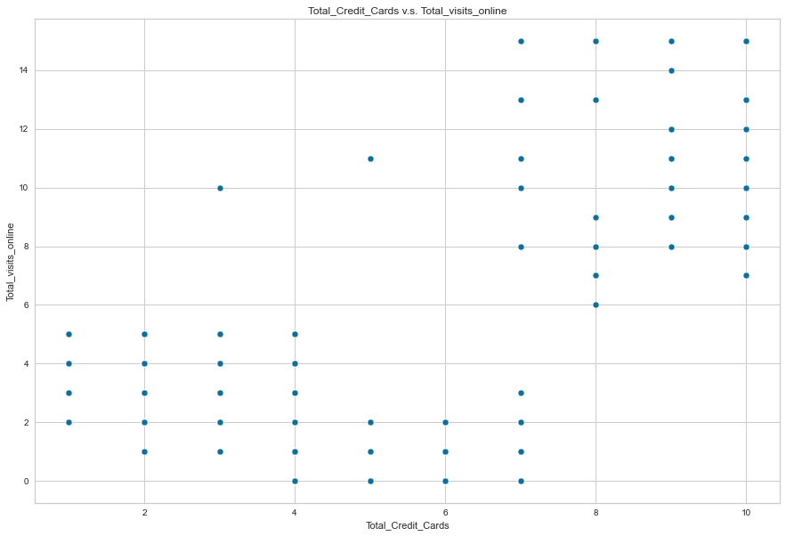

```python
labeled_df           = main_data.copy()
labeled_df['labels'] = 'Normal'

features = {'x':'Total_Credit_Cards', 'y':'Total_visits_online'}
ScatterPlotBeforeOutlierTreatment(labeled_df, features)
```

```python
# Create outlier Constraints
Outlier_Constrains = [
    [
        labeled_df['Total_visits_online'] > 6,
        labeled_df['Total_Credit_Cards'] < 6,
    ]
]
```

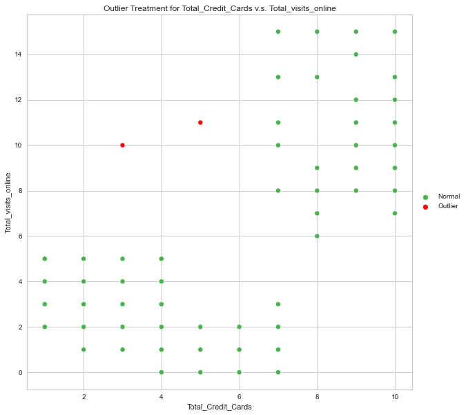

```python
outliers_df = GetOutlierSDataFrame(labeled_df, Outlier_Constrains)

MarkOutliers(
    Outliers_Df = outliers_df,
    Labeled_Df  = labeled_df,
    Features    = features)

Main_Outliers_Df_labeled = MarkOutliers(
    Outliers_Df = outliers_df,
    Labeled_Df  = Main_Outliers_Df_labeled,
    Features    = features,
    ShowPlot    = False)
```

#### Outlier Treatment for Total_calls_made v.s. Total_Credit_Cards

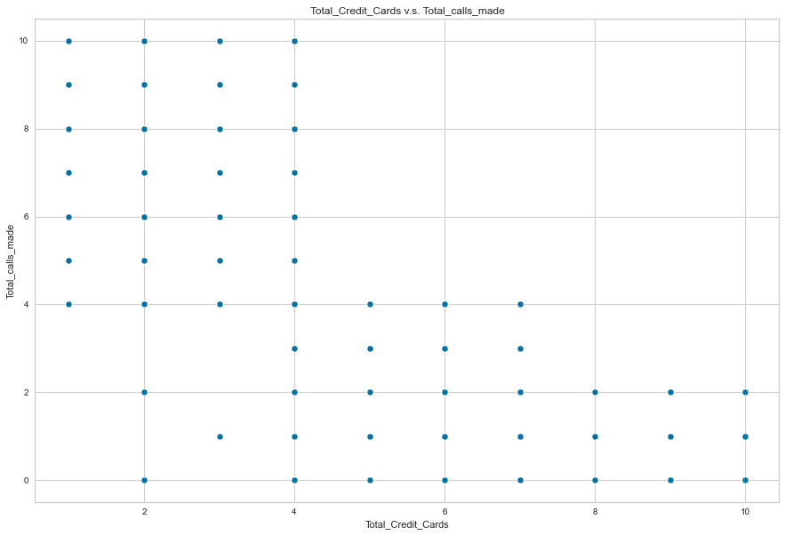

```python
labeled_df           = main_data.copy()
labeled_df['labels'] = 'Normal'

features = {'x':'Total_Credit_Cards', 'y':'Total_calls_made'}
ScatterPlotBeforeOutlierTreatment(labeled_df, features)
```

```python
# Create outlier Constraints
Outlier_Constrains = [
    [
        labeled_df['Total_calls_made'] < 4,
        labeled_df['Total_Credit_Cards'] < 4,
    ]
]
```

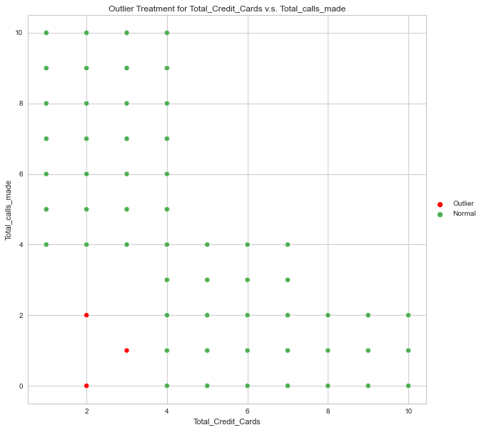

```python
outliers_df = GetOutlierSDataFrame(labeled_df, Outlier_Constrains)

MarkOutliers(
    Outliers_Df = outliers_df,
    Labeled_Df  = labeled_df,
    Features    = features)

Main_Outliers_Df_labeled = MarkOutliers(
    Outliers_Df = outliers_df,
    Labeled_Df  = Main_Outliers_Df_labeled,
    Features    = features,
    ShowPlot    = False)
```

#### Outlier Treatment for Total_visits_online v.s. Total_visits_bank

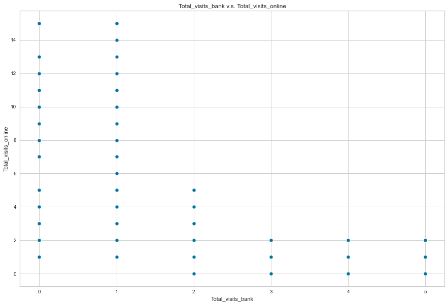

```python
labeled_df           = main_data.copy()
labeled_df['labels'] = 'Normal'

features = {'x':'Total_visits_bank', 'y':'Total_visits_online'}
ScatterPlotBeforeOutlierTreatment(labeled_df, features)
```

#### Outlier Treatment for Total_calls_made v.s. Total_visits_bank

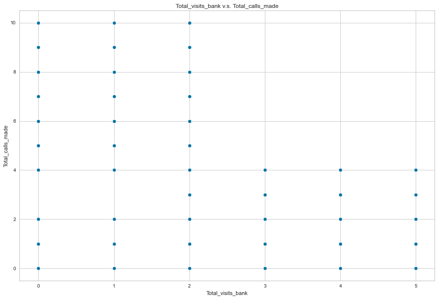

```python
labeled_df           = main_data.copy()
labeled_df['labels'] = 'Normal'

features = {'x':'Total_visits_bank', 'y':'Total_calls_made'}
ScatterPlotBeforeOutlierTreatment(labeled_df, features)
```

#### Outlier Treatment for Total_calls_made v.s. Total_visits_online

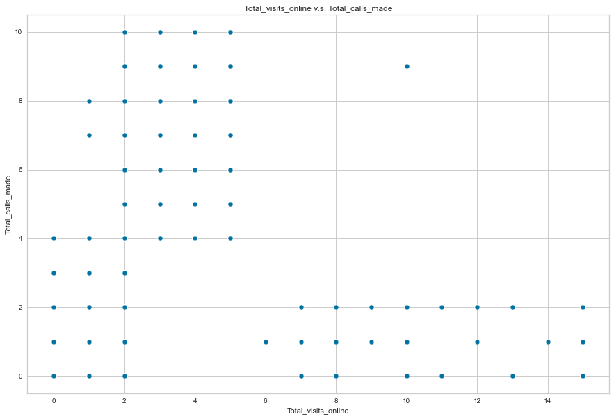

```python
labeled_df           = main_data.copy()
labeled_df['labels'] = 'Normal'

features = {'x':'Total_visits_online', 'y':'Total_calls_made'}
ScatterPlotBeforeOutlierTreatment(labeled_df, features)
```

```python
# Create outlier Constraints
Outlier_Constrains = [
    [
        labeled_df['Total_visits_online'] > 6,
        labeled_df['Total_calls_made'] > 4,
    ]
]
```

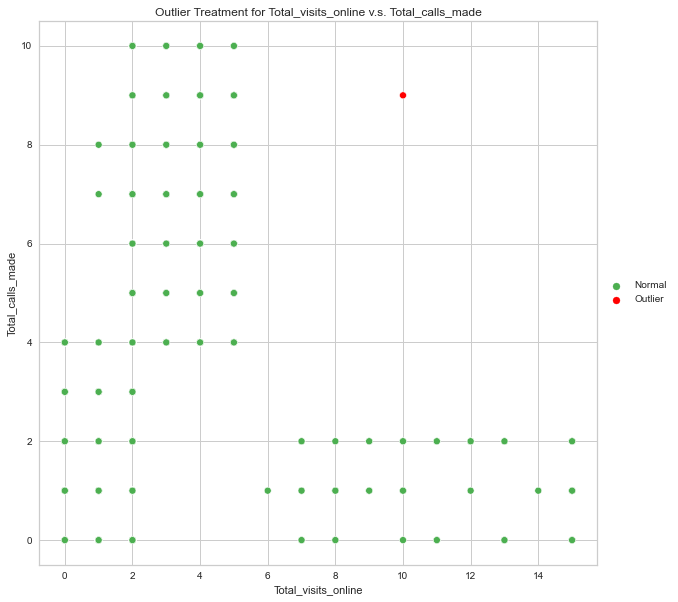

```python
outliers_df = GetOutlierSDataFrame(labeled_df, Outlier_Constrains)

MarkOutliers(
    Outliers_Df = outliers_df,
    Labeled_Df  = labeled_df,
    Features    = features)

Main_Outliers_Df_labeled = MarkOutliers(
    Outliers_Df = outliers_df,
    Labeled_Df  = Main_Outliers_Df_labeled,
    Features    = features,
    ShowPlot    = False)
```

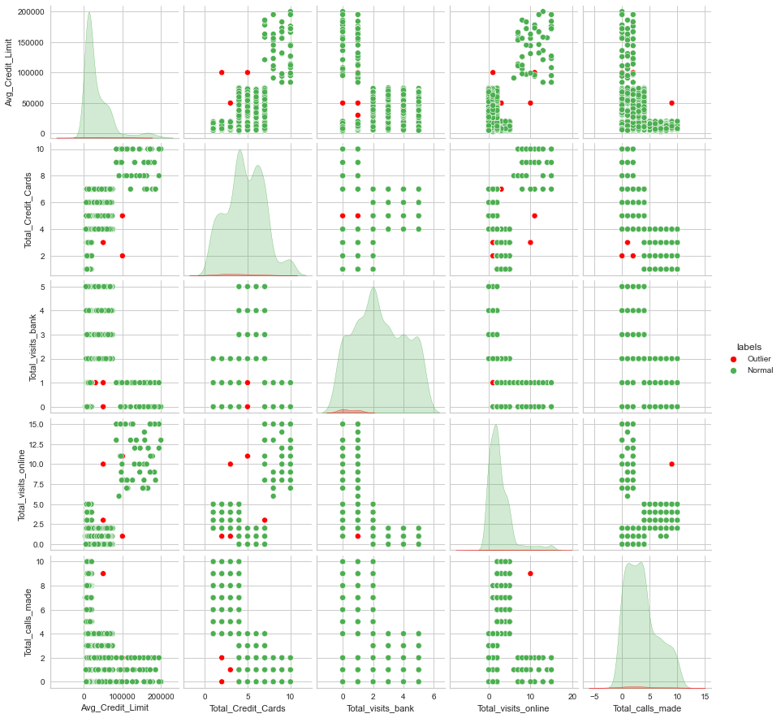

```python
sns.pairplot(
    data    = Main_Outliers_Df_labeled.iloc[:,1:7],
    kind    = "scatter",
    hue     = 'labels',
    palette = outliers_pallete)
```

```python
Main_Outliers_Df_labeled[Main_Outliers_Df_labeled['labels'] == 'Outlier']
```

|  | Customer Key | Avg_Credit_Limit | Total_Credit_Cards | Total_visits_bank | Total_visits_online | Total_calls_made | labels |
| --- | --- | --- | --- | --- | --- | --- | --- |
| 0 | 87073 | 100000 | 2 | 1 | 1 | 0 | Outlier |
| 1 | 38414 | 50000 | 3 | 0 | 10 | 9 | Outlier |
| 2 | 17341 | 50000 | 7 | 1 | 3 | 4 | Outlier |
| 3 | 40496 | 30000 | 5 | 1 | 1 | 4 | Outlier |
| 6 | 48370 | 100000 | 5 | 0 | 11 | 2 | Outlier |
| 7 | 37376 | 15000 | 3 | 0 | 1 | 1 | Outlier |
| 8 | 82490 | 5000 | 2 | 0 | 2 | 2 | Outlier |

```python
# Drop the outliers
Main_Outliers_Df_labeled = Main_Outliers_Df_labeled[Main_Outliers_Df_labeled['labels'] != 'Outlier']
Main_Outliers_Df_labeled[Main_Outliers_Df_labeled['labels'] == 'Outlier']
```

|  | Customer Key | Avg_Credit_Limit | Total_Credit_Cards | Total_visits_bank | Total_visits_online | Total_calls_made | labels |
| --- | --- | --- | --- | --- | --- | --- | --- |

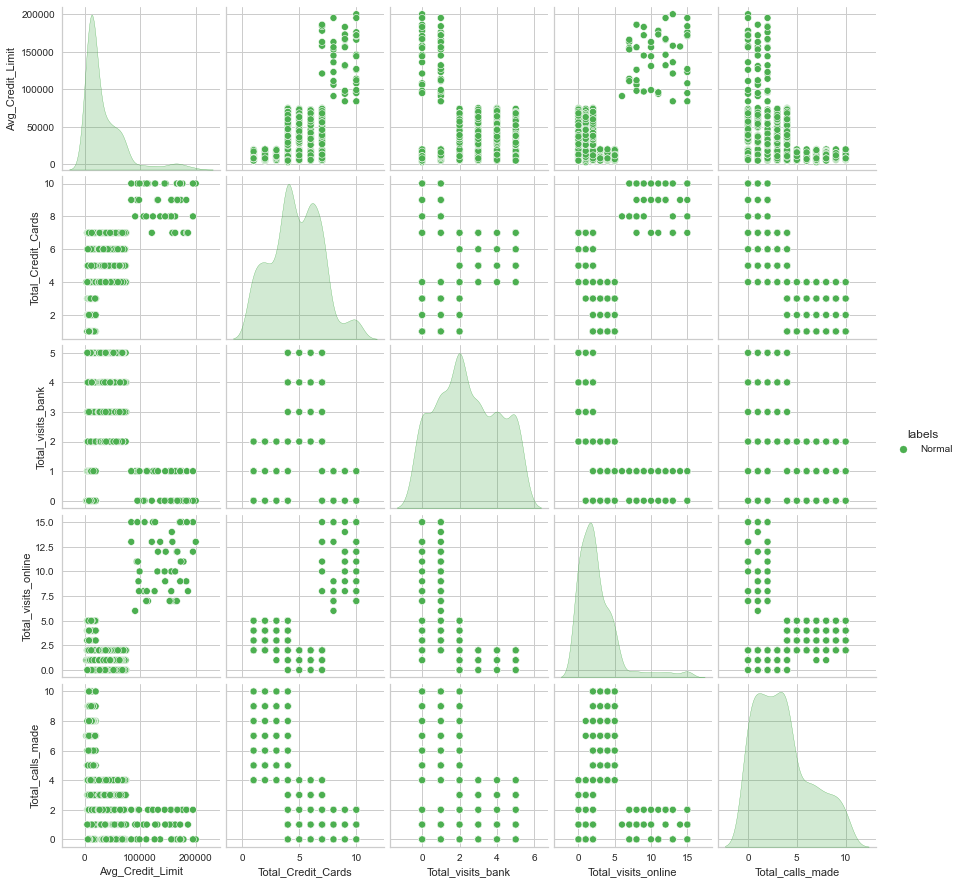

```python
sns.pairplot(
    data    = Main_Outliers_Df_labeled.iloc[:,1:7],
    kind    = "scatter",
    hue     = 'labels',
    palette = outliers_pallete)
```

```python
Main_Outliers_Df_labeled.drop(['labels'], axis=1, inplace=True)
Main_Outliers_Df_labeled.info()
```

```
<class 'pandas.core.frame.DataFrame'>
Int64Index: 643 entries, 5 to 659
Data columns (total 6 columns):
 #   Column               Non-Null Count  Dtype
---  ------               --------------  -----
 0   Customer Key         643 non-null    int64
 1   Avg_Credit_Limit     643 non-null    int64
 2   Total_Credit_Cards   643 non-null    int64
 3   Total_visits_bank    643 non-null    int64
 4   Total_visits_online  643 non-null    int64
 5   Total_calls_made     643 non-null    int64
dtypes: int64(6)
memory usage: 51.3 KB
```

```python
main_data = Main_Outliers_Df_labeled.copy()
```

### Apply Scaling

```python
main_data_scaled = main_data.copy()
main_data_scaled.iloc[:,1:7] = main_data_scaled.iloc[:,1:7].apply(zscore)
main_data_scaled
```

|  | Customer Key | Avg_Credit_Limit | Total_Credit_Cards | Total_visits_bank | Total_visits_online | Total_calls_made |
| --- | --- | --- | --- | --- | --- | --- |
| 5 | 58634 | -0.377713 | -0.784442 | -1.495939 | -0.545939 | 1.540803 |
| 9 | 44770 | -0.834487 | -0.324646 | -1.495939 | -0.545939 | 1.190719 |
| 10 | 52741 | -0.646404 | -0.324646 | -1.495939 | 0.832034 | 0.490552 |
| 11 | 52326 | -0.565797 | -0.784442 | -1.495939 | -0.201446 | 1.190719 |
| 12 | 92503 | -0.619535 | -1.704035 | -0.261957 | 0.832034 | 1.890886 |
| ... | ... | ... | ... | ... | ... | ... |
| 655 | 51108 | 1.744944 | 2.434131 | -0.878948 | 2.554501 | -1.259865 |
| 656 | 60732 | 1.341908 | 2.434131 | -0.878948 | 3.587981 | -0.559698 |
| 657 | 53834 | 2.980921 | 1.514539 | -0.878948 | 2.210007 | -0.909781 |
| 658 | 80655 | 3.706386 | 2.434131 | -0.878948 | 4.276967 | -1.259865 |
| 659 | 80150 | 3.572041 | 1.974335 | -1.495939 | 3.243487 | -0.559698 |

643 rows × 6 columns

```python
main_data_scaled.describe().T[['mean', 'std']]
```

|  | mean | std |
| --- | --- | --- |
| Customer Key | 5.502531e+04 | 25601.968475 |
| Avg_Credit_Limit | -8.702215e-17 | 1.000779 |
| Total_Credit_Cards | 1.668270e-15 | 1.000779 |
| Total_visits_bank | 5.525216e-16 | 1.000779 |
| Total_visits_online | -9.033728e-16 | 1.000779 |
| Total_calls_made | -3.118466e-15 | 1.000779 |

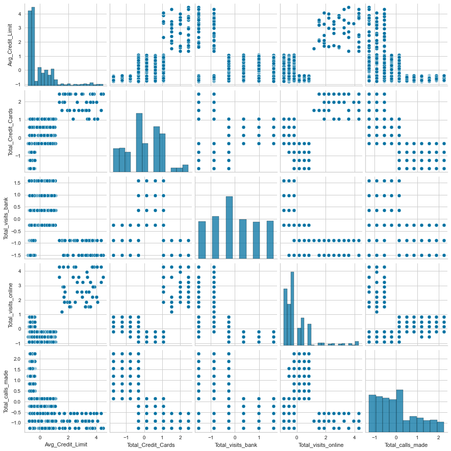

```python
sns.pairplot(
    data    = main_data_scaled.iloc[:,1:7],
    kind    = "scatter",
    palette = outliers_pallete)
```

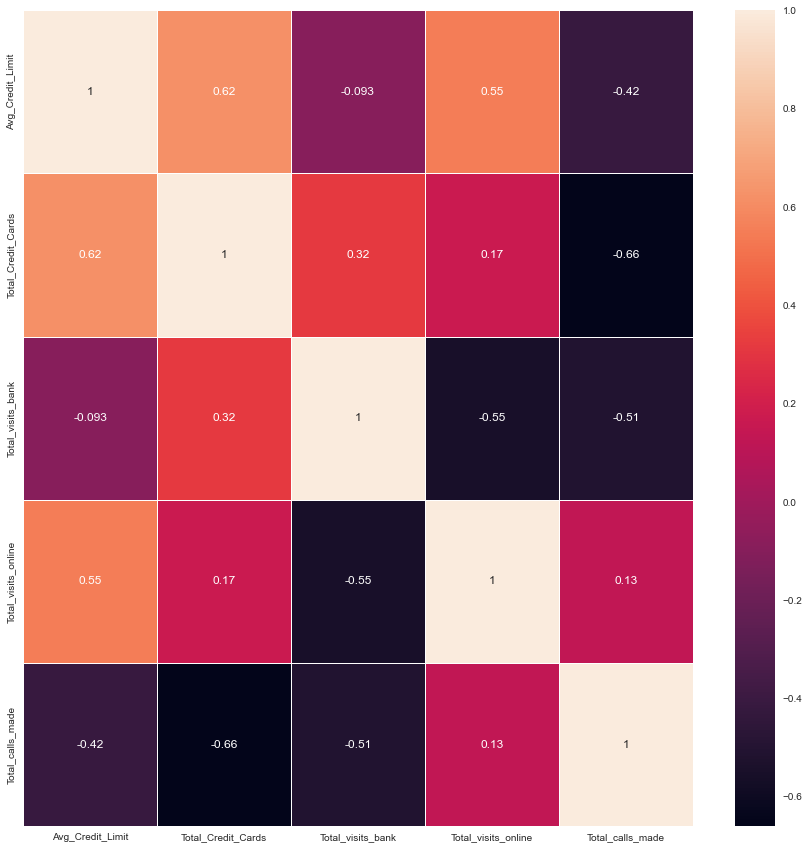

```python
fig, ax = plt.subplots(figsize=(15,15))
sns.heatmap(data=main_data_scaled.iloc[:,1:7].corr(), annot=True, linewidths=.5, ax=ax)
plt.show()
```

### General Observations:

- Customers who own more credit cards have a higher credit limit
- Customers with a higher credit limit and a higher number of credit cards tend to make visit the bank online and make less phone calls to the bank.

## Model Building and Evaluations

## K-Means Clustering

```python
k_means_data_scaled = main_data_scaled.copy()
k_means_data = main_data.copy()
```

```
Number of Clusters: 1 	Average Distortion: 2.0026497808919888
Number of Clusters: 2 	Average Distortion: 1.4444950873503422
Number of Clusters: 3 	Average Distortion: 1.1356773343670947
Number of Clusters: 4 	Average Distortion: 1.0370243964860406
Number of Clusters: 5 	Average Distortion: 0.9817764639187518
Number of Clusters: 6 	Average Distortion: 0.9328887309213009
Number of Clusters: 7 	Average Distortion: 0.9121061223394168
Number of Clusters: 8 	Average Distortion: 0.8787017000499657
```

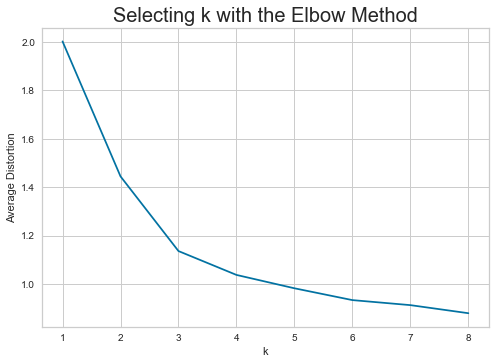

```python
clusters = range(1, 9)
meanDistortions = []
k_means_data_scaled_subset = k_means_data_scaled.iloc[:,1:7].copy()
for k in clusters:
    model = KMeans(n_clusters=k)
    model.fit(k_means_data_scaled_subset)
    prediction = model.predict(k_means_data_scaled_subset)
    distortion = (
        sum(
            np.min(cdist(k_means_data_scaled_subset, model.cluster_centers_, "euclidean"), axis=1)
        )
        / k_means_data_scaled_subset.shape[0]
    )

    meanDistortions.append(distortion)

    print("Number of Clusters:", k, "\tAverage Distortion:", distortion)

plt.plot(clusters, meanDistortions, "bx-")
plt.xlabel("k")
plt.ylabel("Average Distortion")
plt.title("Selecting k with the Elbow Method", fontsize=20)
```

- The elbow curve shows 2 and 3 as the best number of clusters for the dataset.
- Analsing the the kMeans, we see 2 and 3 with the highest scores and 3 clusters having the highestscore.
- We pick 3 as the number of clusters to go with.

```python
scores = []
for k in range(2,6):
    model = KMeans(n_clusters=k, random_state=1)
    model.fit(k_means_data_scaled_subset)
    prediction = model.predict(k_means_data_scaled_subset)
    print(f"k={k}, score={silhouette_score(k_means_data_scaled_subset, prediction)}")
```

```
k=2, score=0.42452202883645235
k=3, score=0.521212069577168
k=4, score=0.35750800227057317
k=5, score=0.27285038395881167
```

```python
kmeans_model = KMeans(n_clusters=3, random_state=1)
kmeans_model.fit(k_means_data_scaled_subset)
```

```
KMeans(n_clusters=3, random_state=1)
```

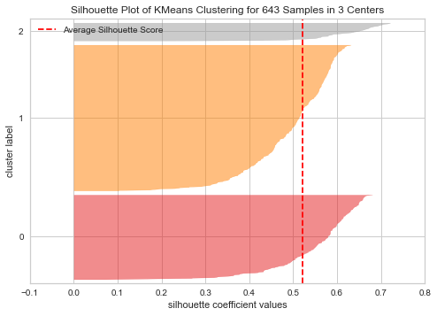

```python
visualizer = SilhouetteVisualizer(kmeans_model)
visualizer.fit(k_means_data_scaled_subset)
visualizer.show()
```